# Conferencias

En esta novena edición de la conferencia contaremos con la presencia de oradores que son referentes en el área de programación con R, con experiencia tanto en el ámbito académico como en la industria y en organizaciones de la sociedad civil. Se destacan por su compromiso con la colaboración y la promoción de ciencia, datos y sofware abiertos.

## Conferencistas

Nic Crane

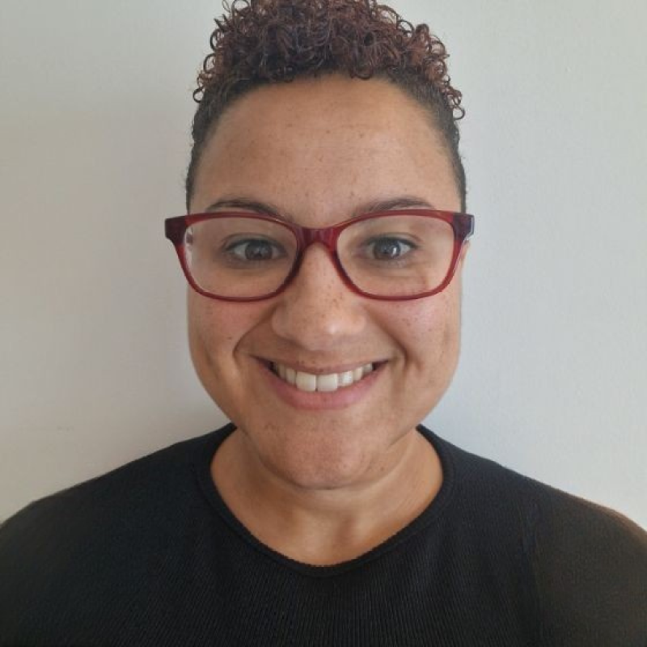

Nic Crane mantiene software de código abierto, realiza consultorías de R y también tiene experiencia como docente. Es parte del Comité de Gestión del Proyecto Apache Arrow y una de las personas que mantiene el paquete Arrow para R, con lo que contribuye al ecosistema general de Arrow y a su adopción en los flujos de trabajo de ciencia de datos. Nic colabora con el paquete ellmer para R e imparte clases y escribe sobre el uso de modelos de lenguaje a gran escala (LLM) en R.

Emil Hvitfeldt

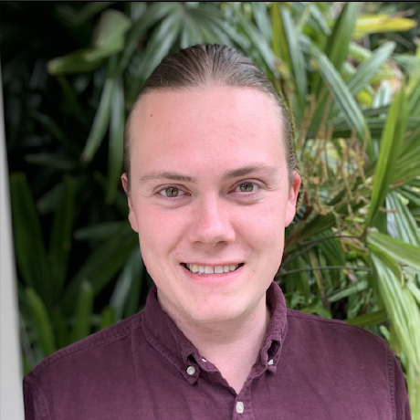

Emil Hvitfeldt es ingeniero de software en Posit y forma parte del equipo de tidymodels, que trabaja para mejorar las capacidades de modelado en R. Mantiene varios paquetes relacionados con el modelado, el análisis de texto y las paletas de colores. También intenta convertir *slidecrafting* en un verbo respetable. Es coautor, junto con Julia Silge, del libro *Supervised Machine Learning for Text Analysis in R*, y actualmente trabaja en el libro *Feature Engineering A-Z*.

Mauricio Gómez Ardila

[figure not shown]

Mauricio Gómez Ardila es especialista de actuaría en Seguros Sura y docente de cátedra en la Facultad de Ingeniería de la Universidad de Antioquia, Colombia. Combina las matemáticas aplicadas y el aprendizaje estadístico para el análisis y solución de problemas financieros y de gestión de riesgos. Su experiencia se centra en el desarrollo de modelos de tarifación de seguros y optimización de reservas técnicas, integrando métodos actuariales con analítica avanzada.

## Conferencias

### Nic Crane: Aprendiendo con IA: Código, Datos y Vida

**12 de noviembre - Parque Explora, 8:30-10:00.**

Hablaré sobre mis experiencias al intentar usar la IA para mejorar mi vida como analista de datos, desarrollador/a de R y ser humano. En una época en la que generar ideas es fácil pero saber cuáles vale la pena perseguir es más difícil, ¿cómo se determina qué merece tu tiempo, qué realmente tendrá un impacto positivo, y cómo lograr que funcione a tu favor y no en tu contra?

### Emil Hvitfeldt: Construyendo software que importa

**12 de noviembre - Parque Explora, 14:00-15:30.**

Construimos software por muchas razones y propósitos diferentes, y cada elección se ve afectada por lo que la precede. Parte del software se escribe para usarse una sola vez y luego descartarse; otro se espera que lo utilicen millones de personas. Debemos tener en cuenta no solo cómo las personas usuarias de nuestras soluciones de software las están usando, sino también cómo se ven afectadas las partes interesadas. ¿Qué sucede cuando dejamos que el código sea caprichoso, sin perder de vista lo que realmente importa?

### Mauricio Gómez Ardila: De la guerra de lenguajes a la sinergia tecnológica

**13 de noviembre - Parque Explora, 16:00-17:30.**

Durante años la discusión fue “¿R o Python?”. La pregunta ya es otra: ¿por qué seguir eligiendo? Esta charla propone ver la ciencia de datos como lo que realmente es: un ecosistema y no un catálogo de herramientas en competencia. Ningún componente tiene valor aislado: la ingesta sostiene el almacenamiento, el almacenamiento habilita el modelado, y el modelado solo importa si llega al despliegue. Cuando una capa madura sin las otras, el sistema completo se desequilibra. La elección del lenguaje es apenas una decisión dentro de ese engranaje, no su eje. Desde esa perspectiva, vamos a recorrer las herramientas que hoy rompen la barrera entre lenguajes. Veremos cómo los equipos productivos dejaron de traducir código y construyeron un pipeline único donde cada pieza hace lo que mejor sabe hacer: el rigor estadístico de R unido a la capacidad de integración y automatización de Python. Los silos de código inevitablemente crean silos de personas. Reconocer esta doble interdependencia (técnica y organizacional) nos lleva a una conclusión definitiva: el mejor pipeline no habla un solo idioma, habla los que el proyecto necesita.